# Elaborate on the output of learn_DAG() using get_ functions

R package: BCDAG vignettes vol.3

2022-05-31

Abstract

This is the third vignettes for the R package BCDAG. In this vignette, we show `how to use the output of learn_DAG() for posterior inference on DAGs, DAG parameters, and causal effect estimation`. Specifically, we introduce the functions of the `get_ family`. Remember that the output of learn_DAG() consists of an MCMC sample from the marginal posterior distribution of DAG structures (collapse = TRUE) and the joint posterior of DAGs and DAG parameters (collapse = FALSE)

**Elaborate on the output of learn_DAG() using get_ functions**  
https://cran.r-project.org/web/packages/BCDAG/vignettes/bcdag_getfamily.html

# 1 Preparations

## 1.1 Packages

## 1.2 Environment

```r
# rgb(73, 81, 112, maxColorValue = 255)
col.tw <- "#dbd7d2"  # Timberwolf
col.os <- "#414a4c"  # Outer Space
col.rp <- "#7851a9"  # Royal Purple
col.mb <- "#1a4876"  # Midnight Blue
col.pb <- "#1ca9c9"  # Pacific Blue
col.cb <- "#b0b7c6"  # Cadet Blue
col.el <- "#ceff1d"  # Electric Lime
col.cg <- "#00cc99"  # Caribbean Green
col.mt <- "#ff8243"  # Mango Tango
col.rm <- "#e3256b"  # Razzmatazz
col.sl <- "#fc2847"  # Scarlet

col.bg <- "#524A4E"  # Background
col.edge <- "#FDEFF4"  # Pale Pink
col.node <- "#4ECCA3"  # Teal

col.plos.yellow <- "#D6E13D"  # PLOS ONE Yellow
col.plos.pink <- "#CF00A3"  # PLOS ONE Pink
col.bmc.gray <- "#FFFDF6"  # BMC Gray
col.bmc.purple <- "#BF12F8"  # BMC Purple
col.bmc.navy <- "#1A2E4F"  # BMC Navy Blue
col.bmc.blue <- "#014A81"  # BMC Blue
col.bmc.sky <- "#0F99BE"  # BMC Sky Blue
col.bmc.green <- "#004940"  # BMC Deep Green
col.bmc.pink <- "#EF255F"  # BMC Pink

font.base <- "Candara"
# font.base <- "Times New Roman"
theme_set(theme_minimal(base_family = font.base))
options(dplyr.summarise.inform = TRUE)
# Twitter Logo and Acc
# Usage: add a code line below
# annotation_custom(grob = icon.grob, xmin = 1, xmax = 1, ymin = 1, ymax = 1)
icon.arr <- png::readPNG("fig/twitter_green.png")
icon.grob <- grid::rasterGrob(icon.arr,
                              width = unit(.55 * 0.5, "cm"),
                              height = unit(0.44 * 0.5, "cm"),
                              interpolate = FALSE)
```

# 2 Generating Data

## 2.1 Generating a binary adjacency matrix w/ `rDAG` function

```r
set.seed(2024)  # for RMarkDown

q <- 10
w <- 0.2
DAG <- rDAG(q = q, w = w)
class(DAG)
```

```
## [1] "matrix" "array"
```

```r
DAG
```

```
##    1 2 3 4 5 6 7 8 9 10
## 1  0 0 0 0 0 0 0 0 0  0
## 2  1 0 0 0 0 0 0 0 0  0
## 3  0 0 0 0 0 0 0 0 0  0
## 4  0 1 1 0 0 0 0 0 0  0
## 5  0 1 0 0 0 0 0 0 0  0
## 6  0 0 0 0 0 0 0 0 0  0
## 7  0 0 0 0 0 0 0 0 0  0
## 8  0 0 0 1 0 0 0 0 0  0
## 9  0 1 0 0 1 1 1 0 0  0
## 10 1 0 1 0 0 0 1 0 1  0
```

```r
DAG.edge.n <- sum(DAG)
```

## 2.2 Visualization of generated DAG via `tidygraph` and `ggraph`

Reference:  
- https://ggplot2-book.org/networks.html#networks  
- https://cran.r-project.org/web/packages/ggraph/vignettes/tidygraph.html

```r
dag.tg <- tidygraph::as_tbl_graph(DAG, directed = TRUE)
class(dag.tg)
```

```
## [1] "tbl_graph" "igraph"
```

```r
dag.tg
```

```
## # A tbl_graph: 10 nodes and 13 edges
## #
## # A directed acyclic simple graph with 1 component
## #
## # Node Data: 10 x 1 (active)
##   name
##   <chr>
## 1 1
## 2 2
## 3 3
## 4 4
## 5 5
## 6 6
## # ... with 4 more rows
## #
## # Edge Data: 13 x 3
##    from    to weight
##   <int> <int>  <dbl>
## 1     2     1      1
## 2     4     2      1
## 3     4     3      1
## # ... with 10 more rows
```

```r
set_graph_style(plot_margin = margin(1, 1, 1, 1))
class(ggraph(dag.tg))
```

```
## [1] "ggraph" "gg"     "ggplot"
```

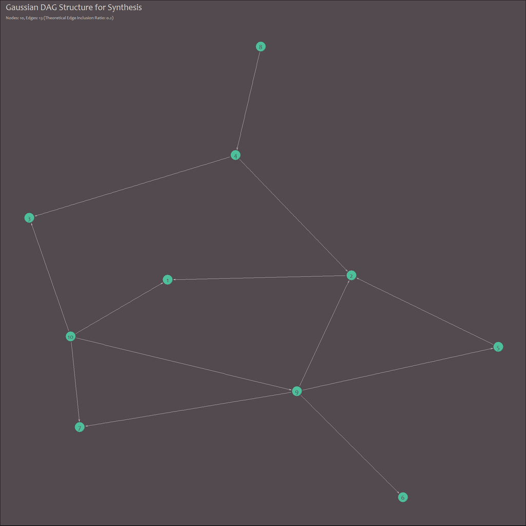

```r
p1 <- ggraph(dag.tg, layout = "fr") +
    geom_edge_link(
        arrow = arrow(angle = 15, length = unit(3, "pt")),
        start_cap = circle(8, "pt"),
        end_cap = circle(8, "pt"),
        color = col.edge,
        edge_width = 0.25, edge_alpha = 0.75
    ) +
    geom_node_point(color = col.node, size = 6, alpha = 0.9) +
    # https://www.rdocumentation.org/packages/ggraph/versions/2.0.5/topics/geom_node_text
    geom_node_text(aes(label = name),
                   size = 3, color = col.bg, family = font.base) +
    theme_minimal(base_family = font.base) +
    labs(title = "Gaussian DAG Structure for Synthesis",
         subtitle = paste0("Nodes: ", as.character(q),
                           ", Edges: ", as.character(DAG.edge.n),
                           " (Theoretical Edge Inclusion Ratio: 0.2)"),
         x = NULL, y = NULL) +
    theme(
        title = element_text(color = col.tw, size = 10),
        plot.subtitle = element_text(color = col.tw, size = 6),
        axis.text = element_blank(),
        panel.grid.major = element_blank(),
        panel.grid.minor = element_blank(),
        plot.background = element_rect(fill = col.bg),
    )

p1
```

```r
ggsave("fig/BCDAG-03-1.png", dpi = 300, width = 3.2, height = 3.6)
```

# 3 Generating Synthetic Data from pre-defined DAG

## 3.1 Generating Gaussian DAG parameters w/ `rDAGWishart` function

```r
set.seed(2024)  # for RMarkDown

a <- q
U <- diag(1, q)
outDL <- rDAGWishart(n = 2, DAG, a, U)
class(outDL)
```

```
## [1] "list"
```

```r
L <- outDL$L
class(L)
```

```
## [1] "array"
```

```r
dim(L)
```

```
## [1] 10 10  2
```

```r
class(L[, , 1])
```

```
## [1] "matrix" "array"
```

```r
diag(L[, , 1])
```

```
##  [1] 1 1 1 1 1 1 1 1 1 1
```

```r
D <- outDL$D
class(D)
```

```
## [1] "array"
```

```r
dim(D)
```

```
## [1] 10 10  2
```

```r
class(D[, , 1])
```

```
## [1] "matrix" "array"
```

```r
sum(D[, , 1] > 0)
```

```
## [1] 10
```

## 3.2 Generating Data from a Gaussian DAG

```r
# Precision matrix: L D^-1 L^T
Omega <- L[, , 1] %*% solve(D[, , 1]) %*% t(L[, , 1])

# Covariance matrix
Sigma <- solve(Omega)

# MultiVariate Normal Distribution
x.mvn <- mvtnorm::rmvnorm(n = 10, sigma = Sigma)
dim(x.mvn)
```

```
## [1] 10 10
```

# 4 MCMC Sampler for DAG Parameters

## 4.1 learn_DAG

```r
tic()
out <- learn_DAG(
    S = 5000,
    burn = 1000,
    data = x.mvn,
    # In this tutorial, these hyperparameter are known.
    a = a, U = U, w = w,
    fast = FALSE, save.memory = FALSE,
    # DAG structures (collapse = TRUE)
    # The joint posterior of DAGs and DAG parameters (collapse = FALSE)
    collapse = FALSE,
    verbose = FALSE
)
toc()
```

```
## 40.62 sec elapsed
```

## 4.2 Outputs

```r
class(out)
```

```
## [1] "bcdag"
```

```r
names(out)
```

```
## [1] "Graphs" "L"      "D"
```

```r
glimpse(out)
```

```
## List of 3
##  $ Graphs: num [1:10, 1:10, 1:5000] 0 1 0 0 0 0 0 0 0 0 ...
##  $ L     : num [1:10, 1:10, 1:5000] 1 0.253 0 0 0 ...
##  $ D     : num [1:10, 1:10, 1:5000] 0.638 0 0 0 0 ...
##  - attr(*, "class")= chr "bcdag"
##  - attr(*, "type")= chr "complete"
##  - attr(*, "input")=List of 10
##   ..$ S          : num 5000
##   ..$ burn       : num 1000
##   ..$ data       : num [1:10, 1:10] 0.1651 -0.0346 2.9319 2.8138 -0.0885 ...
##   ..$ a          : num 10
##   ..$ U          : num [1:10, 1:10] 1 0 0 0 0 0 0 0 0 0 ...
##   ..$ w          : num 0.2
##   ..$ fast       : logi FALSE
##   ..$ save.memory: logi FALSE
##   ..$ collapse   : logi FALSE
##   ..$ verbose    : logi FALSE
```

## 4.3 Visualization of MCMC Sampling

```r
dim(out$Graphs)
```

```
## [1]   10   10 5000
```

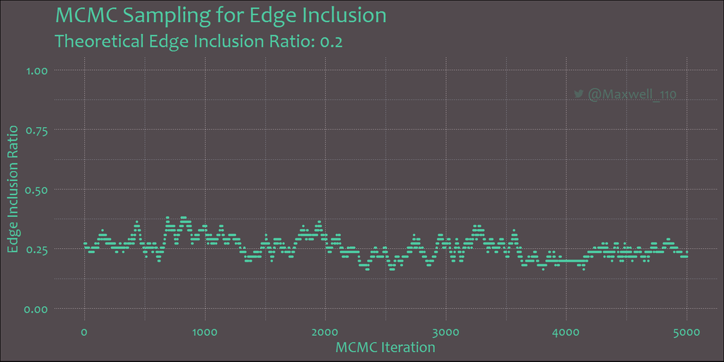

```r
theme_set(theme_minimal(base_family = font.base))

data.frame(
    sample.no = 1:5000,
    inclusion.ratio = colSums(out$Graphs, dims = 2) / (q * (q - 1) / 2 + q)
) %>% ggplot() +
    geom_point(aes(x = sample.no, y = inclusion.ratio),
               color = col.node, size = 0.5) +
    lims(y = c(0, 1)) +
    labs(title = "MCMC Sampling for Edge Inclusion",
         subtitle = paste0("Theoretical Edge Inclusion Ratio: ",
                           as.character(w)),
         x = "MCMC Iteration", y = "Edge Inclusion Ratio") +
    theme(
        title = element_text(color = col.node, size = 15),
        axis.title = element_text(color = col.node, size = 12),
        axis.text = element_text(color = col.node, size = 10),
        panel.grid.minor = element_line(color = col.cb, linetype = 3,
                                        size = 0.1),
        panel.grid.major = element_line(color = col.edge, linetype = 3,
                                        size = 0.1),
        plot.background = element_rect(fill = col.bg)
    ) +
    annotation_custom(grob = icon.grob,
                      xmin = 4100, xmax = 4100,
                      ymin = 0.9, ymax = 0.9) +
    annotate(geom = "text", x = 4550, y = 0.9,
             label = "@Maxwell_110",  alpha = 0.3,
             size = 4, family = "Candara", color = col.node)
```

```r
ggsave("fig/BCDAG-03-2.png", dpi = 300, width = 8, height = 4)
```

# 5 MCMC Diagnostics of Convergence

Before using the MCMC output for posterior inference, it is common practice to perform some convergence checks. Function `get_diagnostics()` provides graphical diagnostics of convergence for the MCMC output of `learn_DAG()`. These are based on:  
- the number of edges in the DAGs  
- the posterior probability of edge inclusion for each possible edge u -> v  
both monitored across MCMC iterations.

Input of the function is an object of class bcdag and the output consists of:  
- a traceplot and running-mean plot of the number of edges in the DAGs (graph size)  
- a collection of traceplots of the posterior probabilities of edge inclusion computed across MCMC iterations

For each pair of distinct nodes (u, v), its posterior probability of inclusion at time s (s = 1, …, S) is estimated as the proportion of DAGs visited by the MCMC up to time s which contain the directed edge u -> v. Output is organized in q plots (one for each node v = 1, …, q), each summarizing the posterior probabilities of edges u -> v (u = 1, …, q).

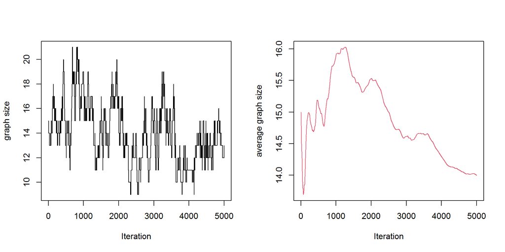

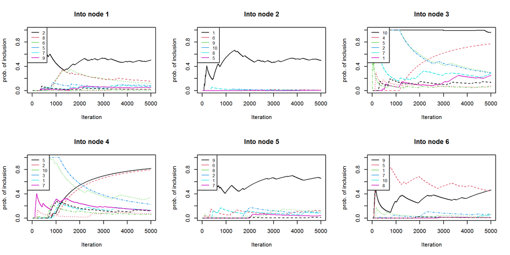

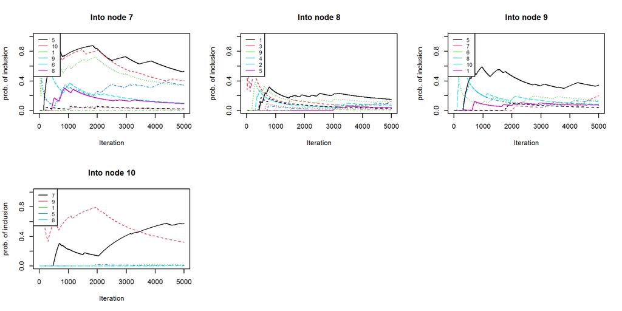

```r
get_diagnostics(out)
```

# 6 Posterior inference: DAG structure learning

## 6.1 summary

We now show how to perform posterior inference of DAGs from the MCMC output.  
To summarize the output of learn_DAG(), a `summary()` method for objects of class bcdag is available. When `summary()` is applied to a bcdag object, a printed message appears. This summarizes the type of bcdag object (see details on bcdag object types provided in the previous vignette) and the input arguments of learn_DAG() that generated the output. In addition, the function returns some graphical outputs representing the Median Probability DAG Model estimate (`MPM`: explained later), the estimated posterior probabilities of edge inclusion and the posterior distribution of the graph size.

```r
summary(out)
```

```
## A  complete  bcdag object containing  5000  draws from the joint posterior over DAGs, L and D. (Burnin = 1000 ).
##
## Prior hyperparameters:
## w =  0.2
## a =  10
## U =      [,1] [,2] [,3] [,4] [,5] [,6] [,7] [,8] [,9] [,10]
##  [1,]    1    0    0    0    0    0    0    0    0     0
##  [2,]    0    1    0    0    0    0    0    0    0     0
##  [3,]    0    0    1    0    0    0    0    0    0     0
##  [4,]    0    0    0    1    0    0    0    0    0     0
##  [5,]    0    0    0    0    1    0    0    0    0     0
##  [6,]    0    0    0    0    0    1    0    0    0     0
##  [7,]    0    0    0    0    0    0    1    0    0     0
##  [8,]    0    0    0    0    0    0    0    1    0     0
##  [9,]    0    0    0    0    0    0    0    0    1     0
## [10,]    0    0    0    0    0    0    0    0    0     1
```

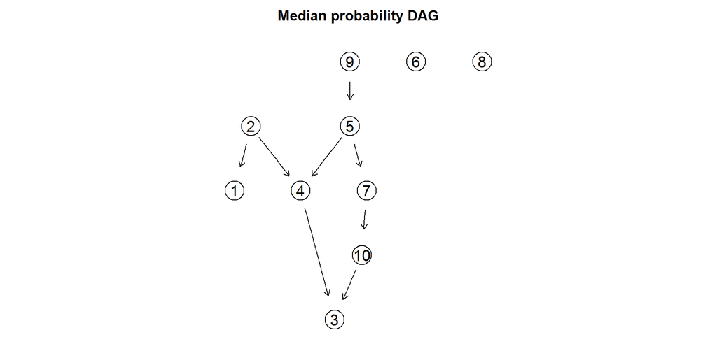

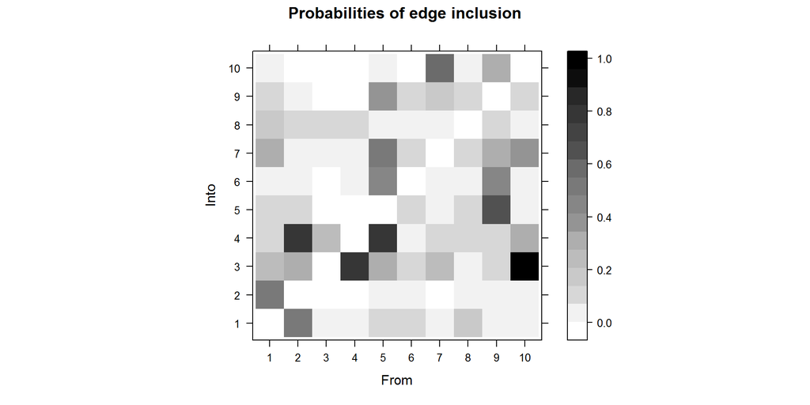

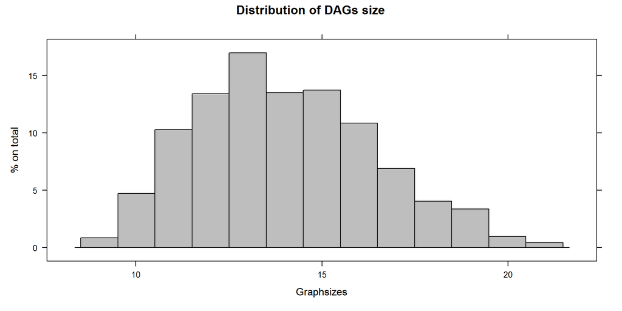

## 6.2 get_edgeprobs

Function `get_edgeprobs()` computes and returns the collection of posterior probabilities of edge inclusion, arranged as a (q, q) matrix, with (u, v)-element referring to edge u -> v

```r
out.edgeprobs <- get_edgeprobs(out)
```

```r
DAG2 <- DAG
rownames(DAG) <- paste0("u", 1:nrow(DAG))
colnames(DAG) <- paste0("v", 1:ncol(DAG))
DAG.df <- reshape2::melt(DAG)

rownames(out.edgeprobs) <- paste0("u", 1:nrow(out.edgeprobs))
colnames(out.edgeprobs) <- paste0("v", 1:ncol(out.edgeprobs))
out.edgeprobs.df <- reshape2::melt(out.edgeprobs)

L1 <- abs(L[, , 1])
rownames(L1) <- paste0("u", 1:nrow(L1))
colnames(L1) <- paste0("v", 1:ncol(L1))
l1.df <- reshape2::melt(L1)
```

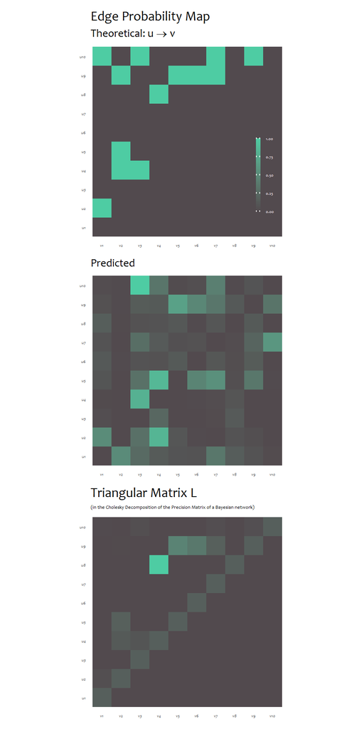

```r
theme_set(theme_minimal(base_family = font.base))

p1 <- ggplot(data = DAG.df) +
    geom_tile(aes(x = Var2, y = Var1, fill = value)) +
    coord_equal() +
    labs(x = NULL, y = NULL, title = "Edge Probability Map",
         subtitle = expression(paste("Theoretical: ", {u %->% v}))) +
    theme(
        panel.grid.minor = element_blank(),
        panel.grid.major = element_blank(),
        axis.text.x = element_text(size = 4, face = "italic"),
        axis.text.y = element_text(size = 4, face = "italic"),
        legend.position = c(0.9, 0.35)
    ) +
    scale_fill_gradient(low = col.bg, high = col.node) +
    guides(
        fill = guide_colourbar(
            title = element_blank(),
            barwidth = 0.3, barheight = 5,
            label.theme = element_text(
                family = font.base, size = 4, color = col.edge
            ),
            label.position = "right",
            ticks.linewidth = 2
        )
    )

p2 <- ggplot(data = out.edgeprobs.df) +
    geom_tile(aes(x = Var2, y = Var1, fill = value)) +
    coord_equal() +
    labs(x = NULL, y = NULL, title = NULL,
         subtitle = "Predicted") +
    theme(
        panel.grid.minor = element_blank(),
        panel.grid.major = element_blank(),
        axis.text.x = element_text(size = 4, face = "italic"),
        axis.text.y = element_text(size = 4, face = "italic"),
        legend.position = "none"
    ) +
    scale_fill_gradient(low = col.bg, high = col.node)


p3 <- ggplot(data = l1.df) +
    geom_tile(aes(x = Var2, y = Var1, fill = value)) +
    coord_equal() +
    labs(x = NULL, y = NULL, title = "Triangular Matrix L",
         subtitle = "(in the Cholesky Decomposition of the Precision Matrix of a Bayesian network)") +
    theme(
        plot.subtitle = element_text(size = 5),
        panel.grid.minor = element_blank(),
        panel.grid.major = element_blank(),
        axis.text.x = element_text(size = 4, face = "italic"),
        axis.text.y = element_text(size = 4, face = "italic"),
        legend.position = "none"
    ) +
    scale_fill_gradient(low = col.bg, high = col.node)

p1 / p2 / p3
```

```r
ggsave("fig/BCDAG-03-3.png", dpi = 300, width = 3.6, height = 3 * 3)
```

## 6.3 get_MPMdag

The MPM model returned in the output of summary() can be used as `a single DAG-model estimate` and is obtained by including all edges whose posterior median probability exceeds the threshold **0.5**. The MPM can be also drew by summary() function as DAG format.  
Function `get_MPMdag()` applies to an object of class bcdag and returns the (q, q) adjacency matrix of the MPM:

```r
MPMdag <- get_MPMdag(out)
sum(MPMdag)
```

```
## [1] 8
```

```r
mpm.dag.tg <- tidygraph::as_tbl_graph(MPMdag, directed = TRUE)
class(mpm.dag.tg)
```

```
## [1] "tbl_graph" "igraph"
```

```r
mpm.dag.tg
```

```
## # A tbl_graph: 10 nodes and 8 edges
## #
## # A directed acyclic simple graph with 3 components
## #
## # Node Data: 10 x 1 (active)
##   name
##   <chr>
## 1 1
## 2 2
## 3 3
## 4 4
## 5 5
## 6 6
## # ... with 4 more rows
## #
## # Edge Data: 8 x 3
##    from    to weight
##   <int> <int>  <dbl>
## 1     2     1      1
## 2     2     4      1
## 3     4     3      1
## # ... with 5 more rows
```

```r
set_graph_style(plot_margin = margin(1, 1, 1, 1))
class(ggraph(mpm.dag.tg))
```

```
## [1] "ggraph" "gg"     "ggplot"
```

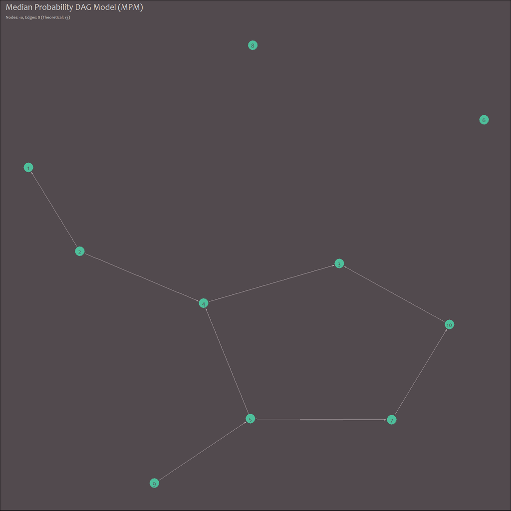

```r
p.mpm <- ggraph(mpm.dag.tg, layout = "fr") +
    geom_edge_link(
        arrow = arrow(angle = 15, length = unit(3, "pt")),
        start_cap = circle(8, "pt"),
        end_cap = circle(8, "pt"),
        color = col.edge,
        edge_width = 0.25, edge_alpha = 0.75
    ) +
    geom_node_point(color = col.node, size = 6, alpha = 0.9) +
    geom_node_text(aes(label = name),
                   size = 3, color = col.bg, family = font.base) +
    theme_minimal(base_family = font.base) +
    labs(title = "Median Probability DAG Model (MPM)",
         subtitle = paste0("Nodes: ", as.character(q),
                           ", Edges: ", as.character(sum(MPMdag)),
                           " (Theoretical: ", as.character(DAG.edge.n), ")"),
         x = NULL, y = NULL) +
    theme(
        title = element_text(color = col.tw, size = 10),
        plot.subtitle = element_text(color = col.tw, size = 6),
        axis.text = element_blank(),
        panel.grid.major = element_blank(),
        panel.grid.minor = element_blank(),
        plot.background = element_rect(fill = col.bg),
    )

p.mpm
```

## 6.4 get_MAPdag

As an alternative, the Maximum A Posterior DAG estimate (MAP) can be considered. This corresponds to the DAG with the highest MCMC frequency of visits and can be recovered through the function get_MAPdag():

```r
MAPdag <- get_MAPdag(out)
sum(MAPdag)
```

```
## [1] 11
```

```r
map.dag.tg <- tidygraph::as_tbl_graph(MAPdag, directed = TRUE)
class(map.dag.tg)
```

```
## [1] "tbl_graph" "igraph"
```

```r
map.dag.tg
```

```
## # A tbl_graph: 10 nodes and 11 edges
## #
## # A directed acyclic simple graph with 1 component
## #
## # Node Data: 10 x 1 (active)
##   name
##   <chr>
## 1 1
## 2 2
## 3 3
## 4 4
## 5 5
## 6 6
## # ... with 4 more rows
## #
## # Edge Data: 11 x 3
##    from    to weight
##   <int> <int>  <dbl>
## 1     2     1      1
## 2     2     4      1
## 3     4     3      1
## # ... with 8 more rows
```

```r
set_graph_style(plot_margin = margin(1, 1, 1, 1))
class(ggraph(map.dag.tg))
```

```
## [1] "ggraph" "gg"     "ggplot"
```

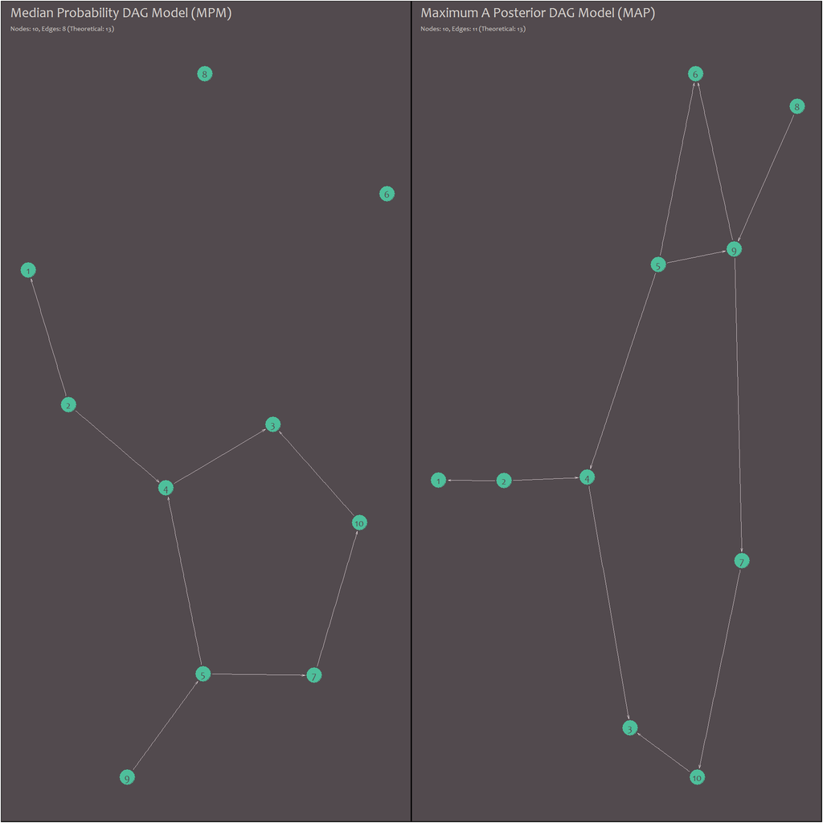

```r
p.map <- ggraph(map.dag.tg, layout = "fr") +
    geom_edge_link(
        arrow = arrow(angle = 15, length = unit(3, "pt")),
        start_cap = circle(8, "pt"),
        end_cap = circle(8, "pt"),
        color = col.edge,
        edge_width = 0.25, edge_alpha = 0.75
    ) +
    geom_node_point(color = col.node, size = 6, alpha = 0.9) +
    geom_node_text(aes(label = name),
                   size = 3, color = col.bg, family = font.base) +
    theme_minimal(base_family = font.base) +
    labs(title = "Maximum A Posterior DAG Model (MAP)",
         subtitle = paste0("Nodes: ", as.character(q),
                           ", Edges: ", as.character(sum(MAPdag)),
                           " (Theoretical: ", as.character(DAG.edge.n), ")"),
         x = NULL, y = NULL) +
    theme(
        title = element_text(color = col.tw, size = 10),
        plot.subtitle = element_text(color = col.tw, size = 6),
        axis.text = element_blank(),
        panel.grid.major = element_blank(),
        panel.grid.minor = element_blank(),
        plot.background = element_rect(fill = col.bg),
    )

p.mpm + p.map
```

```r
ggsave("fig/BCDAG-03-4.png", dpi = 300, width = 3.2 * 2, height = 3.6)
```

# 7 Posterior inference: causal effect estimation

In this last section, we introduce functions `causaleffect()` and `get_causaleffect()`, which allow to compute and estimate causal effects between variables. Specifically, we consider the causal effect on a response variable of interest consequent to a joint intervention on a given set of variables; see also Nandy et al. (2017) and Castelletti & Mascaro (2021) for formal definitions.

For a given DAG, it is possible to identify and estimate the causal effect on a node Y consequent to a hypothetical hard intervention on node j using the rules of the **do-calculus** (Pearl, 2000).  
A simple implementation of this set of rules and an estimation method for the causally sufficient case and for Gaussian data is provided by function `causaleffect()`.  
The function takes as input;  
- a numerical vector representing the labels of the intervened nodes (also called intervention target)  
- a numerical value indicating the response variable  
- the DAG model parameters L and D  
see also Castelletti & Mascaro (2021) or our previous vignette for a detailed model description.

## 7.1 Understand the Difference between Single and Joint Interventions

To better understand the difference between single and joint interventions, consider as an example the total causal effect on node Y = 1 (i.e. variable X_1) of a joint intervention on nodes X_i and X_j. And the total causal effects of two separate interventions on nodes X_i and X_j under the causal model represented by the DAG generated before:

```r
# Joint
causaleffect(targets = c(2, 7), response = 1,
             L = L[, , 1], D = D[, , 1])
```

```
## [1] -0.2222904  0.0000000
```

```r
# Single
causaleffect(targets = c(2), response = 1,
             L = L[, , 1], D = D[, , 1])
```

```
## [1] -0.2222904
```

```r
causaleffect(targets = c(7), response = 1,
             L = L[, , 1], D = D[, , 1])
```

```
## [1] 0
```

The total causal effects produced are thus exactly the same for both variables in the two cases. However, if we slightly modify the DAG by adding an edge from node i to node j, so that:

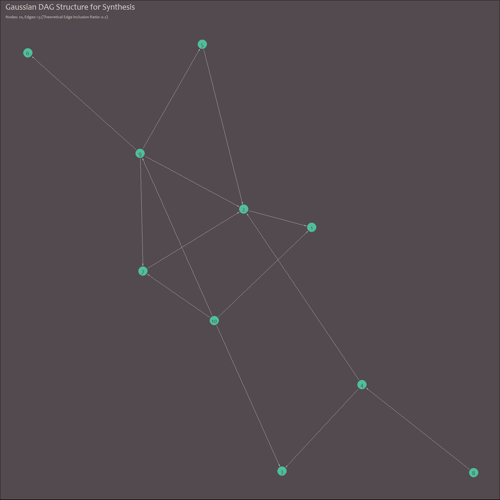

```r
# i = 7, j = 2
DAG2[7, 2] <- 1
dag2.tg <- tidygraph::as_tbl_graph(DAG2, directed = TRUE)

set_graph_style(plot_margin = margin(1, 1, 1, 1))

ggraph(dag2.tg, layout = "fr") +
    geom_edge_link(
        arrow = arrow(angle = 15, length = unit(3, "pt")),
        start_cap = circle(8, "pt"),
        end_cap = circle(8, "pt"),
        color = col.edge,
        edge_width = 0.25, edge_alpha = 0.75
    ) +
    geom_node_point(color = col.node, size = 6, alpha = 0.9) +
    geom_node_text(aes(label = name),
                   size = 3, color = col.bg, family = font.base) +
    theme_minimal(base_family = font.base) +
    labs(title = "Gaussian DAG Structure for Synthesis",
         subtitle = paste0("Nodes: ", as.character(q),
                           ", Edges: ", as.character(DAG.edge.n),
                           " (Theoretical Edge Inclusion Ratio: 0.2)"),
         x = NULL, y = NULL) +
    theme(
        title = element_text(color = col.tw, size = 10),
        plot.subtitle = element_text(color = col.tw, size = 6),
        axis.text = element_blank(),
        panel.grid.major = element_blank(),
        panel.grid.minor = element_blank(),
        plot.background = element_rect(fill = col.bg),
    )
```

```r
set.seed(2022)
L2 <- L
L2[7, 2, 1] <- runif(1)
print(L2[7, 2, 1])
```

```
## [1] 0.8159777
```

```r
# Joint
causaleffect(targets = c(2, 7), response = 1,
             L = L2[, , 1], D = D[, , 1])
```

```
## [1] -0.2222904  0.0000000
```

```r
# Single
causaleffect(targets = c(2), response = 1,
             L = L2[, , 1], D = D[, , 1])
```

```
## [1] -0.2222904
```

```r
causaleffect(targets = c(7), response = 1,
             L = L2[, , 1], D = D[, , 1])  # != 0
```

```
## [1] 0.181384
```

As it can be observed, this time a single intervention on X_7 produces a non-zero causal effect on X_1, while jointly intervening on X_2 and X_7 makes the total causal effect of X_7 on X1 zero. The effect of X_7 on X_1 was in fact mediated by X_2.

## 7.2 Esitimate Causal Effects

The identification and estimation of causal effects requires the specification of a DAG. When the DAG is unknown, function `get_causaleffect()` can be used. It applies to objects of class `bcdag`; the latter corresponds to the output of learn_DAG() and consists of a sample of size S from the posterior of DAGs and DAG parameters. In addition get_causaleffect() takes as input a numerical vector representing the labels of the intervened nodes (the intervention target) and a numerical value indicating the response variable. **Output of the get_causaleffect() function** is a sample of size S from the posterior distribution of the causal effect coefficients associated with the intervention targets:

```r
effects_out <- get_causaleffect(out, targets = c(2, 7), response = 1)
head(effects_out)
```

```
##           h = 2 h = 7
## [1,] -0.2528500     0
## [2,] -0.2462446     0
## [3,] -0.2067692     0
## [4,] -0.2309205     0
## [5,] -0.2329004     0
## [6,] -0.2207196     0
```

Additionally, if BMA = TRUE, get_causaleffect() returns a Bayesian Model Average (BMA) estimate of the causal effect coefficients:

```r
## BMA estimate of causal effects
round(get_causaleffect(
    out, targets = c(2, 7), response = 1, BMA = TRUE
), 3)
```

```
##  h = 2  h = 7
## -0.120 -0.014
```

```r
## True causal effects
round(causaleffect(
    targets = c(2, 7), response = 1, L = L[, , 1], D = D[, , 1]
), 3)
```

```
## [1] -0.222  0.000
```

# 8 References

- Castelletti, F, Mascaro, A (2021). “Structural learning and estimation of joint causal effects among network-dependent variables”. Statistical Methods & Applications, 30(5), 1289-1314.
- Castelletti F, Mascaro A (2022). “BCDAG: An R package for Bayesian structural and Causal learning of Gaussian DAGs.” arXiv pre-print.
- Nandy, P, Maathuis, MH., Richardson, TS (2017). “Estimating the effect of joint interventions from observational data in sparse high-dimensional settings”. The Annals of Statistics, 45(2), 647-674.
- Pearl J (2000). Causality: Models, Reasoning, and Inference. Cambridge University Press, Cambridge. ISBN 0-521-77362-8.